# Mental Health attendances in urgent and emergency care settings

Author

Andy Hood et al

Published

2024-07-22

## Introduction

The care quality commission (CQC) are looking to supplement their State of Care (SOC) report with relevant additional data and analysis. The latest state of care report can be found here https://www.cqc.org.uk/publications/major-report/state-care/2022-2023.

One of the key areas of interest is around perceived ‘system failure’ as measured by (inappropriate/avoidable?) attendance to urgent and emergency care settings for people with mental health problems.

## Data and methods

We summarised routine data from the Emergency Care Dataset (ECDS), NHS 111 dataset and the Mental Health Services Dataset (MHSDS) via NCDR https://www.ardengemcsu.nhs.uk/services/business-intelligence/ncdr/ according to specific population sub-groups and activity break-downs at Integrated Care Board (ICB) level. The period covers the 5 financial years from 1st April 2019 to 31st March 2024.

Patients were linked using common pseudonymised ID from ECDS and NHS111 to the MHSDS to establish whether they were known to specialist mental health services (referred and/or treated) or not.

The presence of a presenting mental health problem in **A&E data** was determined by all descendant SNOMED codes (n=1580) for ‘Mental Health Disorders’ in either the Chief Complaint field *OR* the 1st Diagnosis field. Codes relating to dementia, memory & cognition OR substance misuse were excluded.

The presence of mental health in **NHS 111 data** were established using a bespoke reference set for the symptom group comprising the specific mental health groups *AND* additional mentions of anxiety, depression, stress, suicidal thoughts or mental health in other symptom groups. Codes relating to dementia, memory & cognition AND substance misuse were excluded.

Denominator data on population numbers by sub-group (age, gender, imd decile, urban-rural) were sourced from ONS mid-year estimates at LSOA level grouped to 2023 ICB boundaries. As 2023 MYE has not yet been published for LSOA, the 2022 data has been rolled forward as a proxy. For ethnic category populations, the 2011 and 2021 census data has been used to impute linear estimates of the intervening and following years. Calendar year data has been fully attributed to the financial year in which it falls e.g. 2021 = 2021/22.

## Accident and Emergency attendance

These attendances are those specified within the ECDS as ‘Type 1’ emergency department attendances and typically should be for those patients with life-threatening symptoms or injuries requiring immediate triage and treatment.

The average A&E attendance in England costs £280 with those conveyed by ambulance costing an additional £390 https://www.england.nhs.uk/costing-in-the-nhs/national-cost-collection/.

Top 10 SNOMED codes in A&E presentation

All of England, 2023/24

| SNOMED_term | attends |
| --- | --- |
| Depressive disorder (disorder) | 78386 |
| Anxiety disorder (disorder) | 59987 |
| Psychotic disorder (disorder) | 19011 |
| Dissociative convulsions (disorder) | 11288 |
| Panic disorder (disorder) | 6965 |
| Personality disorder (disorder) | 6265 |
| Schizophrenia (disorder) | 4840 |
| Bipolar disorder (disorder) | 3863 |
| Eating disorder (disorder) | 3262 |
| Somatoform pain disorder (disorder) | 1162 |

### Key metrics

#### Arrival mode to ED

Data is captured in ECDS for the mode of transport used to get the patient to the department categorised to ambulance conveyance, self-conveyance and by public transport. Breakdowns by population demographics can be seen in Section 4.2.3.

**All modes**

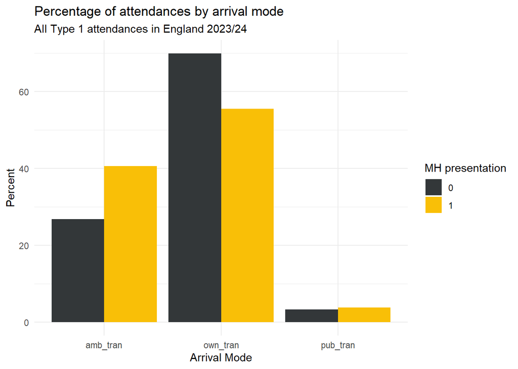

**Trend**

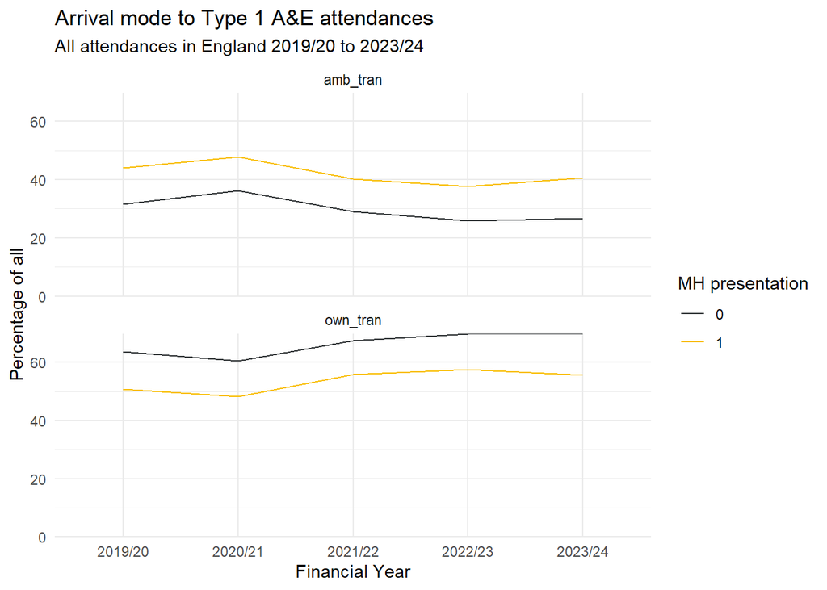

**Table**

```
# A tibble: 30 × 5
# Groups:   mh_snomed, der_financial_year [10]
   mh_snomed arrival_mode der_financial_year  attends  perc
       <int> <chr>        <chr>                 <int> <dbl>
 1         0 amb_tran     2019/20             4409282  31.5
 2         0 amb_tran     2020/21             4076974  36.3
 3         0 amb_tran     2021/22             4390492  29.0
 4         0 amb_tran     2022/23             3984699  25.9
 5         0 amb_tran     2023/24             4143660  26.8
 6         0 own_tran     2019/20             8916670  63.7
 7         0 own_tran     2020/21             6802304  60.5
 8         0 own_tran     2021/22            10226688  67.4
 9         0 own_tran     2022/23            10726323  69.8
10         0 own_tran     2023/24            10800738  69.9
# ℹ 20 more rows
```

#### Time of arrival

Patients presenting with mental health complaints are more likely to attend after 8pm and before 6am than their contemporaries with physical health complaints - this could be suggestive of lesser access to out-of-hours psychiatric and crisis support or the increased likelihood of crisis occurring when people are alone.

**Chart**

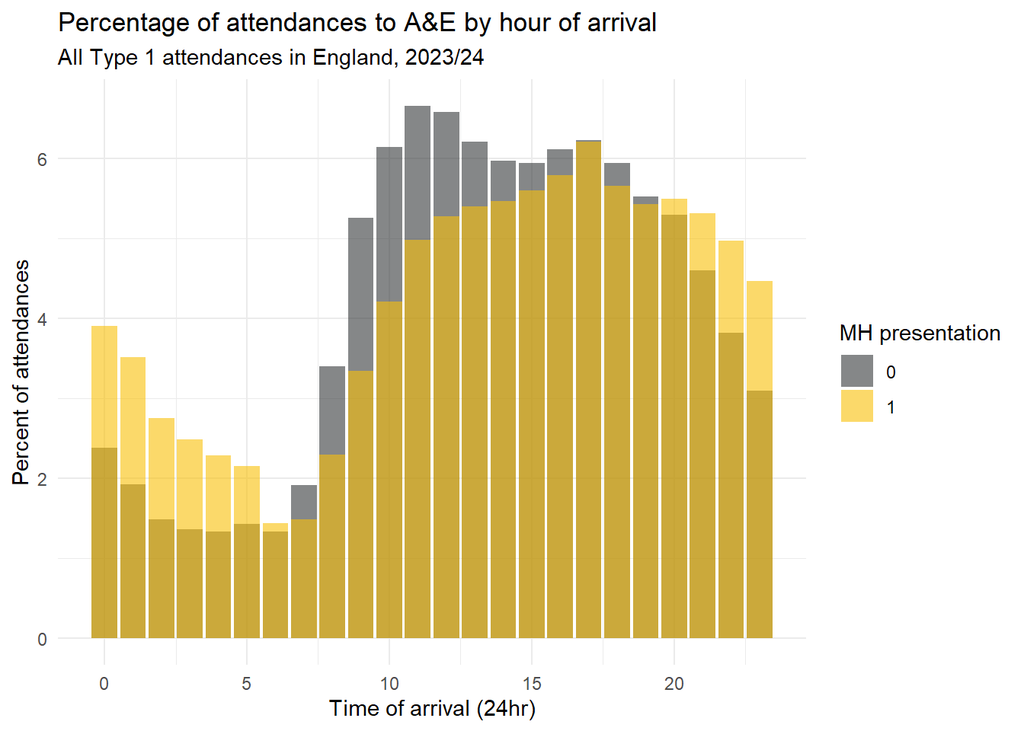

**Table**

```
# A tibble: 48 × 4
# Groups:   mh_snomed [2]
   mh_snomed   toa attends  perc
       <int> <int>   <int> <dbl>
 1         0     0  372774  2.39
 2         0     1  300506  1.92
 3         0     2  232791  1.49
 4         0     3  213349  1.37
 5         0     4  208426  1.33
 6         0     5  224275  1.44
 7         0     6  208231  1.33
 8         0     7  299349  1.92
 9         0     8  531730  3.40
10         0     9  822356  5.26
# ℹ 38 more rows
```

#### Leaving the department

SNOMED departure status codes allow us to identify patients that left the department before either assessment or treatment was completed.

**Chart**

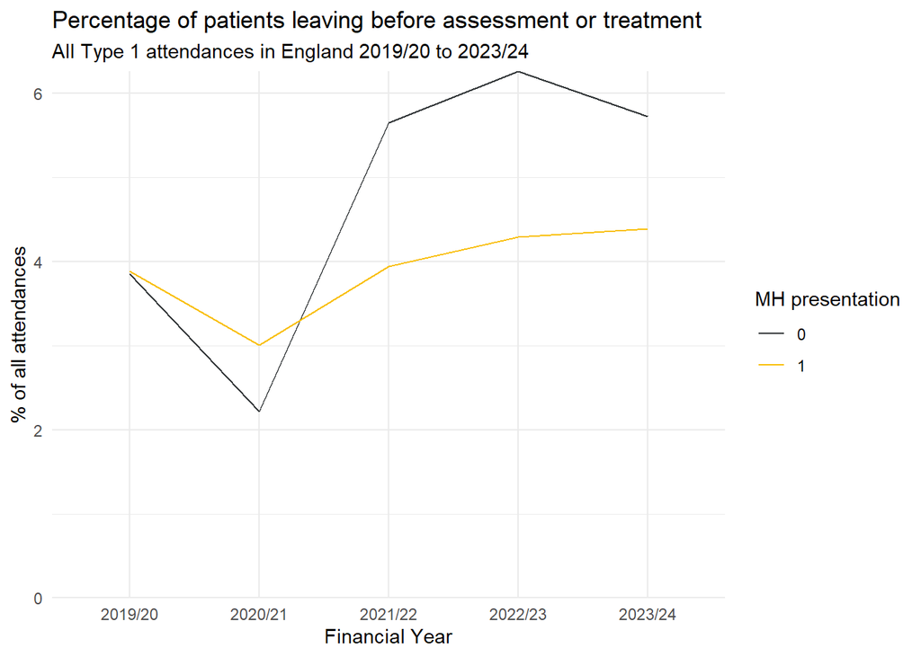

**Table**

```
# A tibble: 10 × 10
   mh_snomed der_financial_year  attends   left value lowercl uppercl confidence
       <int> <chr>                 <int>  <int> <dbl>   <dbl>   <dbl> <chr>
 1         0 2019/20            14483274 558553  3.86    3.85    3.87 95%
 2         0 2020/21            11482600 254839  2.22    2.21    2.23 95%
 3         0 2021/22            15243185 862228  5.66    5.64    5.67 95%
 4         0 2022/23            15433536 966285  6.26    6.25    6.27 95%
 5         0 2023/24            15625442 894316  5.72    5.71    5.73 95%
 6         1 2019/20              205244   7980  3.89    3.81    3.97 95%
 7         1 2020/21              196640   5914  3.01    2.93    3.08 95%
 8         1 2021/22              210672   8306  3.94    3.86    4.03 95%
 9         1 2022/23              193439   8311  4.30    4.21    4.39 95%
10         1 2023/24              194714   8557  4.39    4.30    4.49 95%
# ℹ 2 more variables: statistic <chr>, method <chr>
```

#### Waiting times in ED

The ECDS allows calculation of times from arrival to assessment, treatment, conclusion and to departure.

**Assessment**

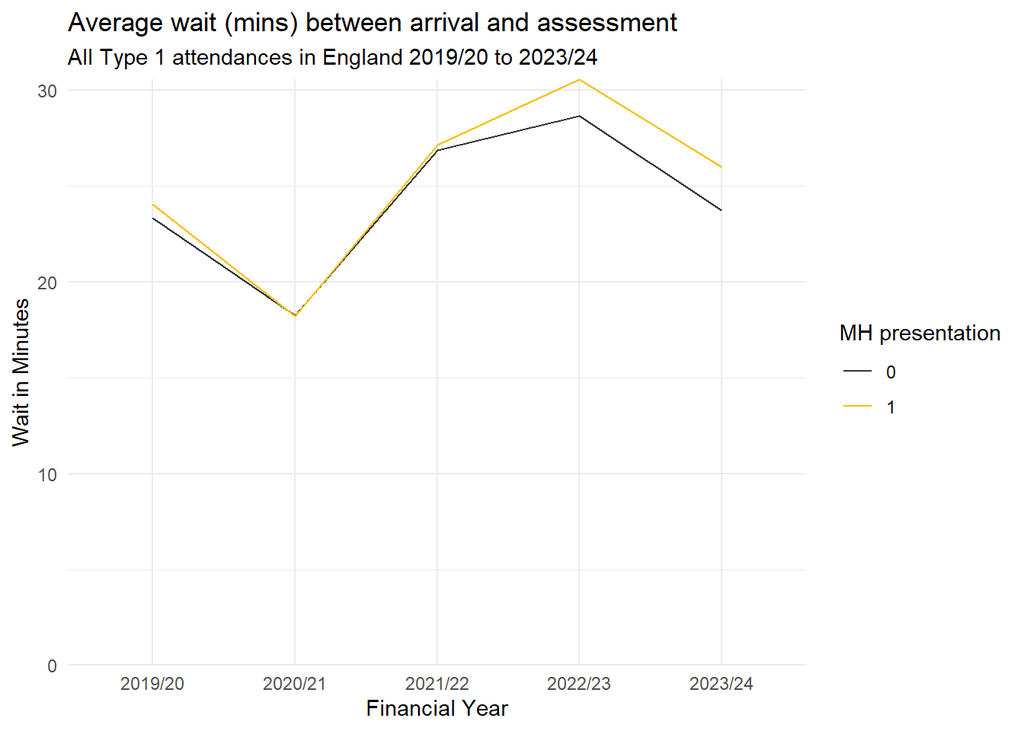

**Treatment**

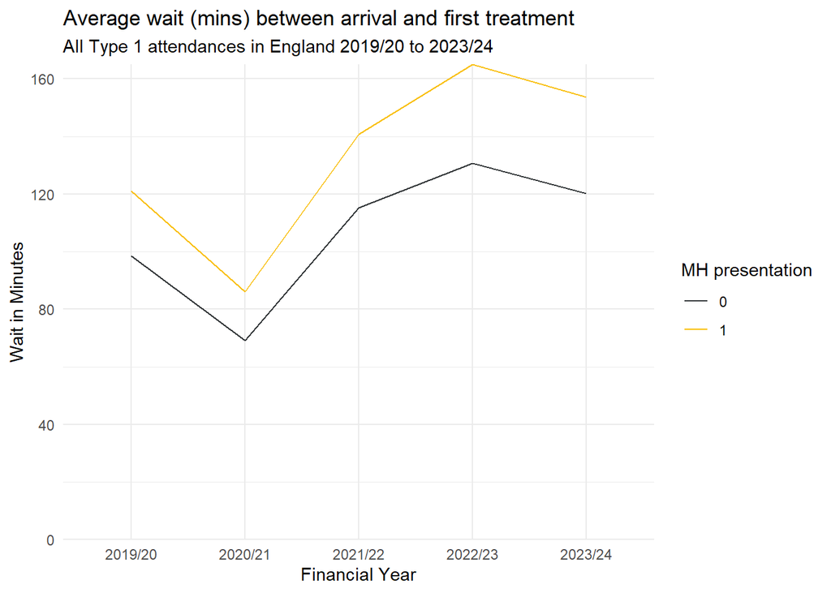

**Conclusion**

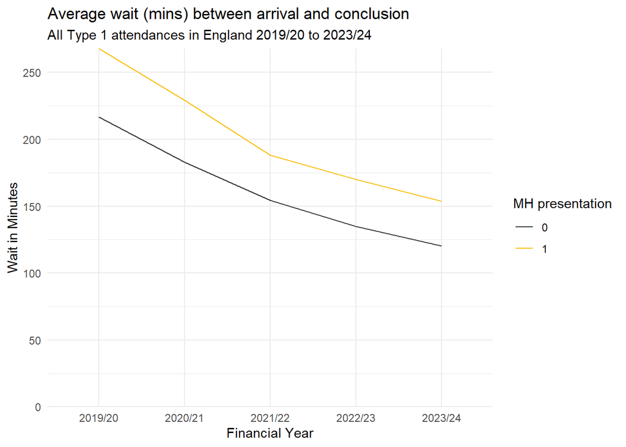

**Departure**

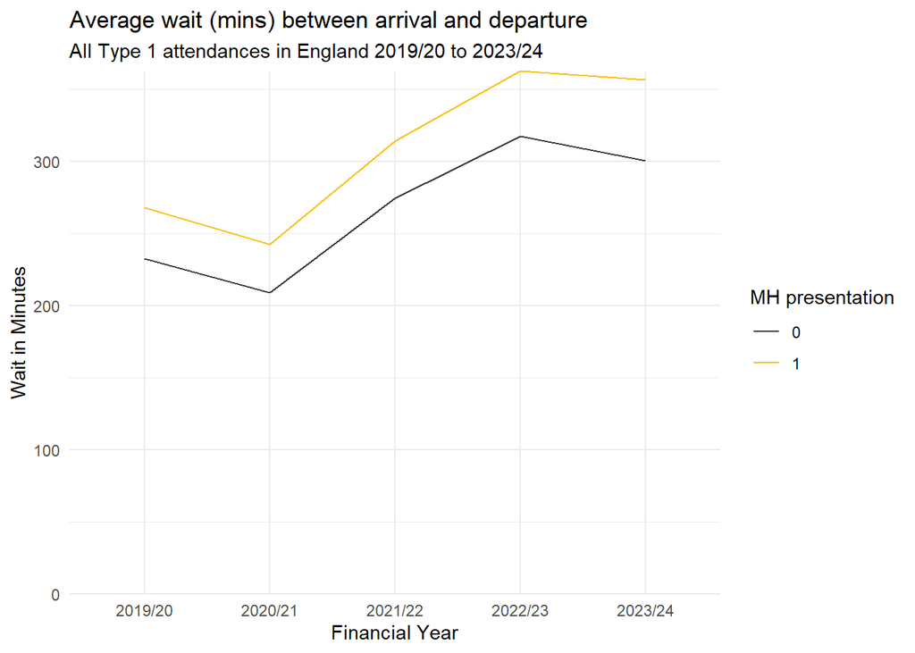

#### Mental health ‘frequent fliers’

Frequent fliers can be defined as those attending 5 or more times in a 12 month period with a primary complaint/diagnosis of mental health disorders.

Over the past 5 years in England, on average, there are 209,346 patients presenting with a mental health problem. Of these around 2,208 ( 1.1% ) are those who attend frequently. This varies by ICB area.

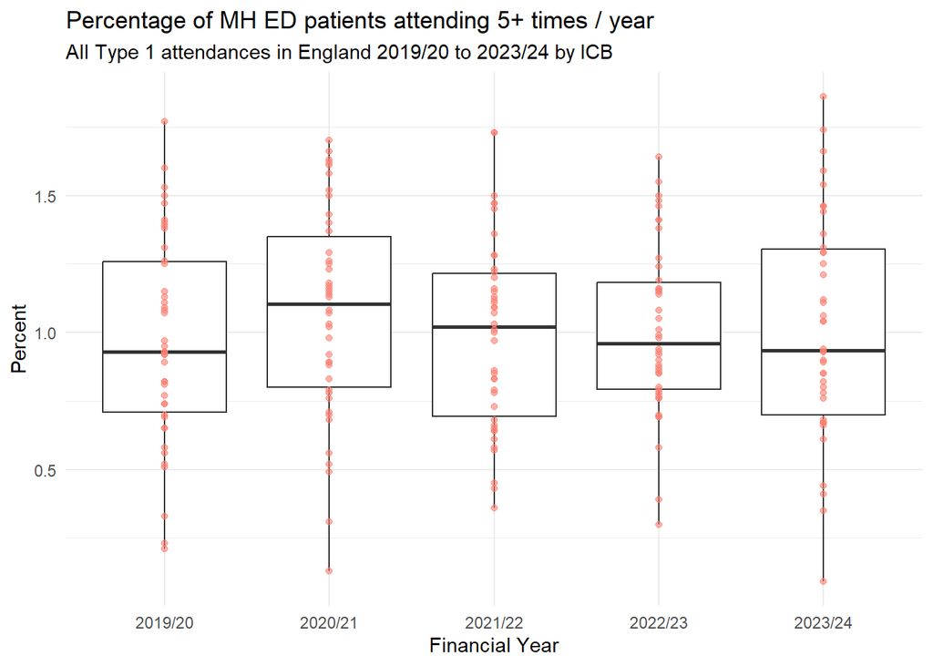

### Detailed breakdowns

#### Percentage of all Type 1 attendances with Mental Health as primary reason/diagnosis

Figure 1 suggests the median percentage of Type 1 attendances with Mental Health as the primary reason/diagnosis is comparable with pre-pandemic levels. Breakdowns by ICB are in **?@tbl-type1-perc** and breakdowns by population demographics below.

**Overview**

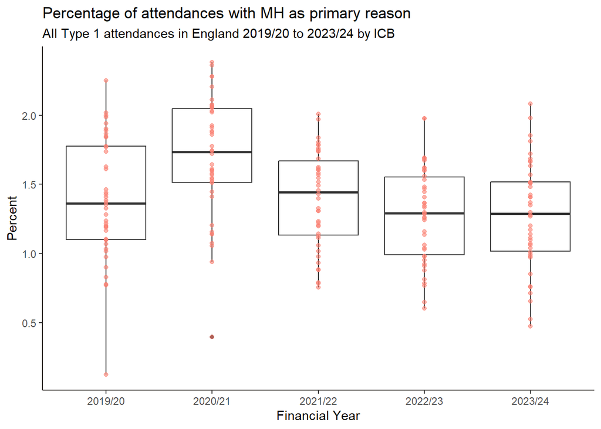

Figure 1: Percentage of Mental Health Type 1 attendances over time.

**ICB Variation**

| ICB | 2019/20 | 2020/21 | 2021/22 | 2022/23 | 2023/24 |
| --- | --- | --- | --- | --- | --- |
| NHS Sussex Integrated Care Board | 2.02 | 2.38 | 2.01 | 1.98 | 2.08 |
| NHS Cornwall and the Isles of Scilly Integrated Care Board | 2.25 | 2.05 | 1.97 | 1.98 | 1.98 |
| NHS Hampshire and Isle of Wight Integrated Care Board | 1.89 | 1.91 | 1.76 | 1.69 | 1.85 |
| NHS Norfolk and Waveney Integrated Care Board | 1.99 | 2.07 | 1.79 | 1.69 | 1.81 |
| NHS Devon Integrated Care Board | 1.94 | 1.51 | 1.6 | 1.62 | 1.72 |
| NHS Bristol North Somerset and South Gloucestershire Integrated Care Board | 1.87 | 2.28 | 1.6 | 1.6 | 1.69 |
| NHS South East London Integrated Care Board | 1.39 | 1.89 | 1.49 | 1.6 | 1.67 |
| NHS Birmingham and Solihull Integrated Care Board | 1.85 | 2.28 | 1.81 | 1.56 | 1.66 |
| NHS Northamptonshire Integrated Care Board | 1.77 | 2.36 | 1.74 | 1.68 | 1.63 |
| NHS Lincolnshire Integrated Care Board | 1.84 | 2.03 | 1.84 | 1.62 | 1.57 |

[output cut: 32 more lines]

Breakdowns for the number of Type 1 attendances with MH as primary reason/diagnosis are below.

##### Geographical variation

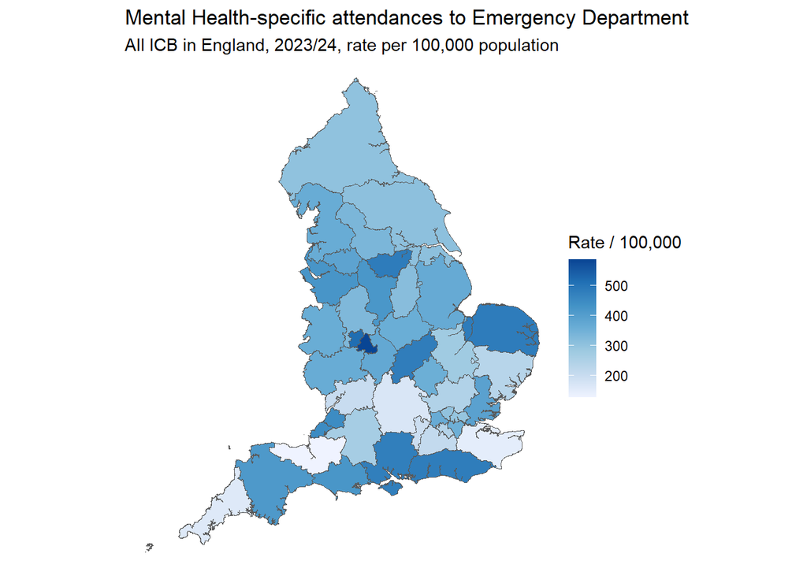

**Gender variation**

**Chart**

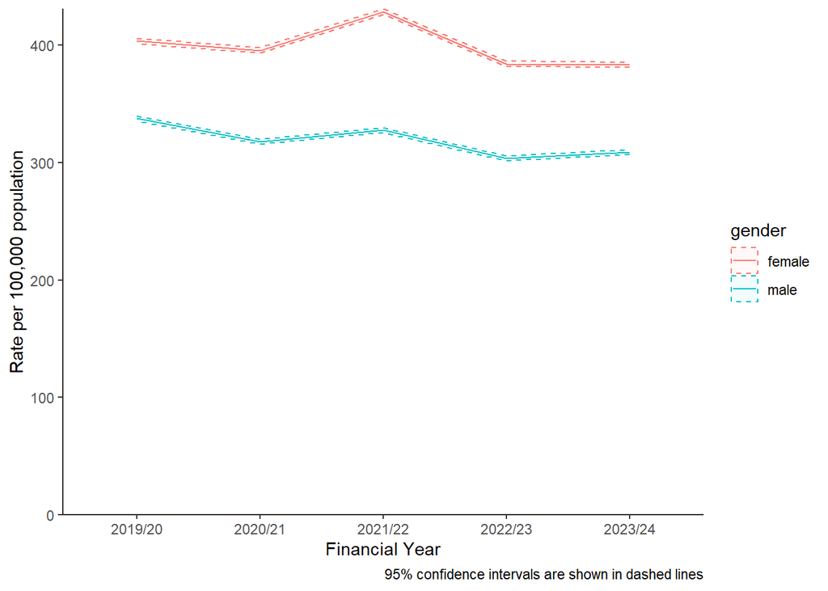

Figure 2: Rates per 100,000 population of the number of Mental Health Type 1 attendances by gender.

**Table**

| der_financial_year | gender | attends | count | value | lowercl | uppercl |
| --- | --- | --- | --- | --- | --- | --- |
| 2019/20 | female | 114874 | 28459130 | 403.65 | 401.31 | 405.99 |
| 2020/21 | female | 112996 | 28567320 | 395.54 | 393.24 | 397.86 |
| 2021/22 | female | 123757 | 28871204 | 428.65 | 426.27 | 431.05 |
| 2022/23 | female | 111856 | 29123108 | 384.08 | 381.83 | 386.34 |
| 2023/24 | female | 111673 | 29123108 | 383.45 | 381.21 | 385.71 |
| 2019/20 | male | 93961 | 27827831 | 337.65 | 335.5 | 339.82 |
| 2020/21 | male | 88879 | 27982818 | 317.62 | 315.54 | 319.71 |
| 2021/22 | male | 90706 | 27683687 | 327.65 | 325.52 | 329.79 |
| 2022/23 | male | 84984 | 27983290 | 303.7 | 301.66 | 305.74 |
| 2023/24 | male | 86496 | 27983290 | 309.1 | 307.04 | 311.17 |

**Age-group variation**

**Chart**

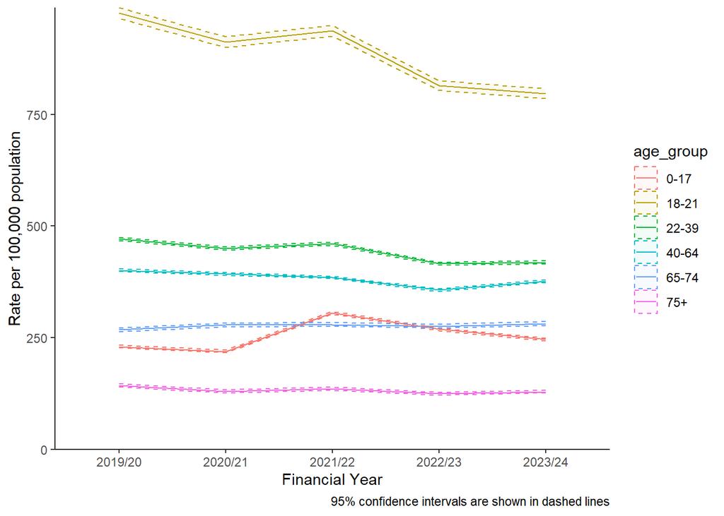

Figure 3: Rates per 100,000 population of the number of Mental Health Type 1 attendances by age group.

**Table**

| der_financial_year | age_group | attends | count | value | lowercl | uppercl |
| --- | --- | --- | --- | --- | --- | --- |
| 2019/20 | 0-17 | 27683 | 12023568 | 230.24 | 227.54 | 232.97 |
| 2020/21 | 0-17 | 26516 | 12093288 | 219.26 | 216.63 | 221.92 |
| 2021/22 | 0-17 | 35991 | 11762878 | 305.97 | 302.82 | 309.15 |
| 2022/23 | 0-17 | 31976 | 11886906 | 269 | 266.06 | 271.97 |
| 2023/24 | 0-17 | 29242 | 11886906 | 246 | 243.19 | 248.84 |
| 2019/20 | 18-21 | 25464 | 2606458 | 976.96 | 964.99 | 989.03 |
| 2020/21 | 18-21 | 23442 | 2569709 | 912.24 | 900.6 | 924 |
| 2021/22 | 18-21 | 24370 | 2600225 | 937.23 | 925.5 | 949.07 |
| 2022/23 | 18-21 | 21549 | 2645130 | 814.67 | 803.83 | 825.62 |
| 2023/24 | 18-21 | 21083 | 2645130 | 797.05 | 786.33 | 807.88 |

[output cut: 20 more lines]

**Ethnic group variation**

**Chart**

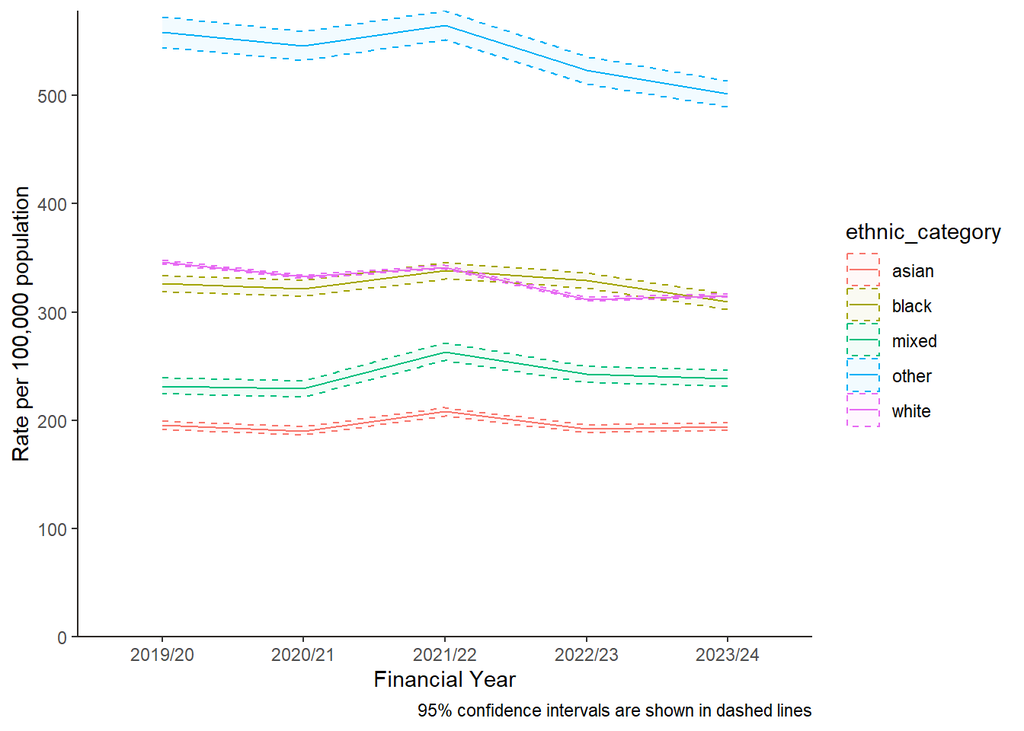

Figure 4: Rates per 100,000 population of the number of Mental Health Type 1 attendances by ethnic category.

**Table**

| der_financial_year | ethnic_category | attends | count | value | lowercl | uppercl |
| --- | --- | --- | --- | --- | --- | --- |
| 2019/20 | asian | 10098 | 5169879 | 195.32 | 191.53 | 199.17 |
| 2020/21 | asian | 10073 | 5298188.5 | 190.12 | 186.43 | 193.87 |
| 2021/22 | asian | 11291 | 5426498 | 208.07 | 204.25 | 211.95 |
| 2022/23 | asian | 10660 | 5554807.5 | 191.91 | 188.28 | 195.58 |
| 2023/24 | asian | 11032 | 5683117 | 194.12 | 190.51 | 197.78 |
| 2019/20 | black | 7418 | 2274658.8 | 326.11 | 318.74 | 333.62 |
| 2020/21 | black | 7488 | 2328164.4 | 321.63 | 314.38 | 329 |
| 2021/22 | black | 8052 | 2381670 | 338.08 | 330.74 | 345.55 |
| 2022/23 | black | 8016 | 2435175.6 | 329.18 | 322.01 | 336.46 |
| 2023/24 | black | 7700 | 2488681.2 | 309.4 | 302.53 | 316.39 |

[output cut: 15 more lines]

**Socioeconomic variation**

**Chart1**

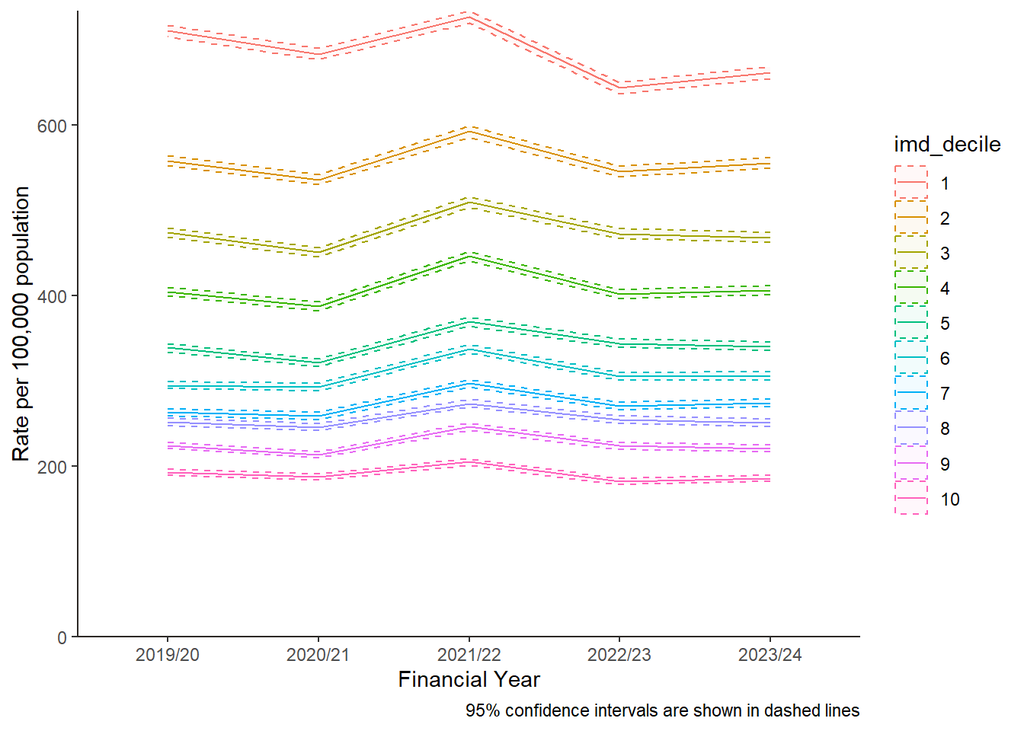

Figure 5: Rates per 100,000 population of the number of Mental Health Type 1 attendances by Index of Multiple Deprivation decile.

**Chart2**

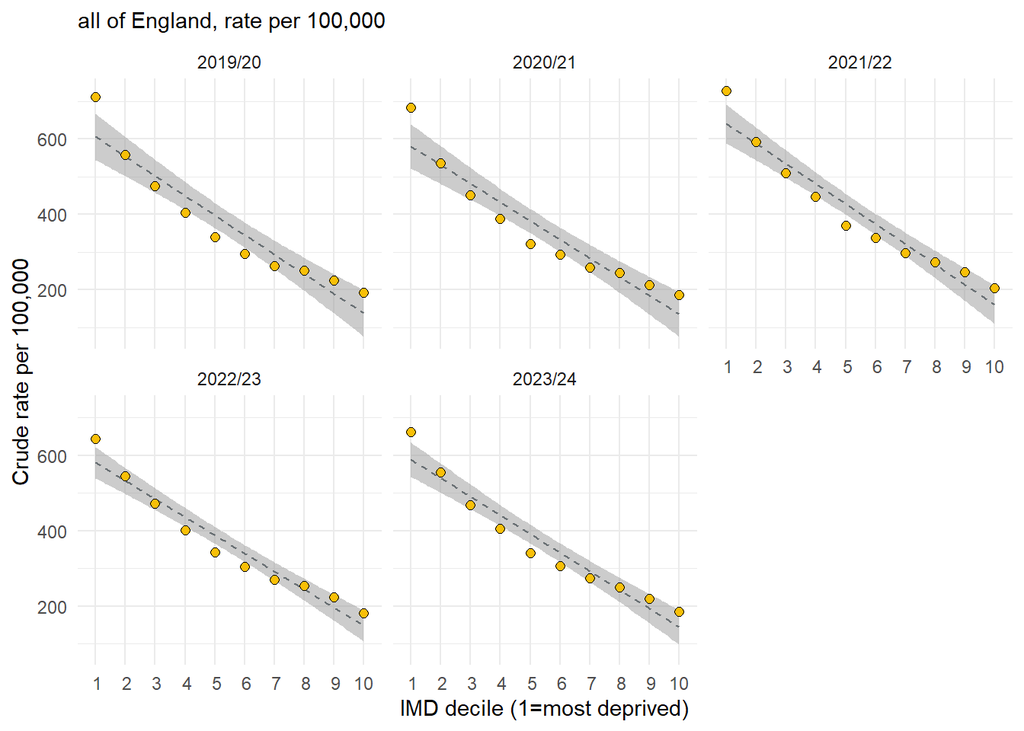

**Table**

| der_financial_year | imd_decile | attends | count | value | lowercl | uppercl |
| --- | --- | --- | --- | --- | --- | --- |
| 2019/20 | 1 | 39714 | 5588091 | 710.69 | 703.72 | 717.71 |
| 2020/21 | 1 | 38317 | 5603911 | 683.75 | 676.93 | 690.64 |
| 2021/22 | 1 | 39218 | 5394735 | 726.97 | 719.79 | 734.2 |
| 2022/23 | 1 | 35102 | 5453738 | 643.63 | 636.92 | 650.4 |
| 2023/24 | 1 | 36099 | 5453738 | 661.91 | 655.1 | 668.78 |
| 2019/20 | 2 | 31721 | 5677439 | 558.72 | 552.59 | 564.9 |
| 2020/21 | 2 | 30550 | 5697232 | 536.23 | 530.23 | 542.27 |
| 2021/22 | 2 | 32140 | 5422810 | 592.68 | 586.22 | 599.2 |
| 2022/23 | 2 | 29831 | 5463929 | 545.96 | 539.78 | 552.19 |
| 2023/24 | 2 | 30380 | 5463929 | 556.01 | 549.78 | 562.3 |

[output cut: 40 more lines]

**Rural-urban variation**

**Chart**

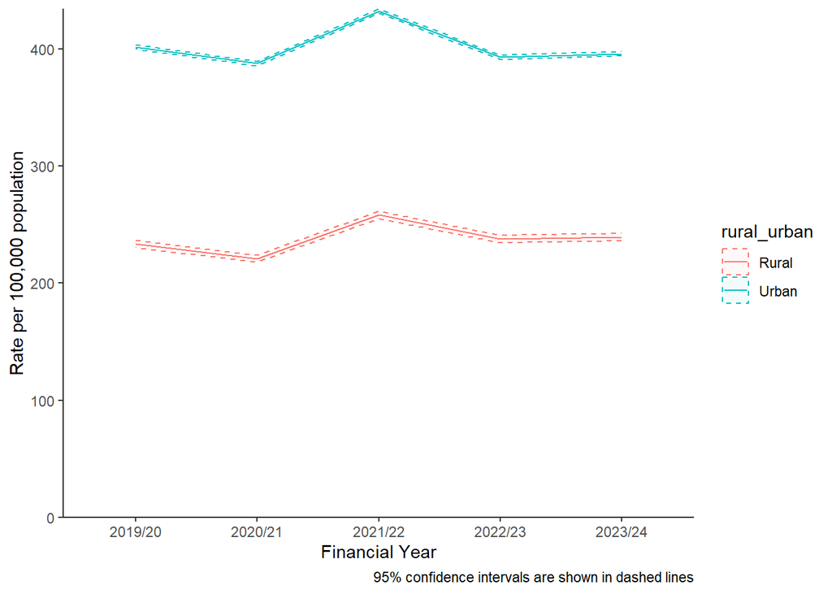

Figure 6: Rates per 100,000 population of the number of Mental Health Type 1 attendances by rural and urban populations.

**Table**

| der_financial_year | rural_urban | attends | count | value | lowercl | uppercl |
| --- | --- | --- | --- | --- | --- | --- |
| 2019/20 | Rural | 22429 | 9608249 | 233.43 | 230.39 | 236.51 |
| 2020/21 | Rural | 21406 | 9683314 | 221.06 | 218.11 | 224.04 |
| 2021/22 | Rural | 23777 | 9201537 | 258.4 | 255.13 | 261.71 |
| 2022/23 | Rural | 22055 | 9279480 | 237.67 | 234.55 | 240.83 |
| 2023/24 | Rural | 22224 | 9279480 | 239.5 | 236.36 | 242.67 |
| 2019/20 | Urban | 187560 | 46678712 | 401.81 | 399.99 | 403.63 |
| 2020/21 | Urban | 181707 | 46866824 | 387.71 | 385.93 | 389.5 |
| 2021/22 | Urban | 191136 | 44203614 | 432.4 | 430.46 | 434.34 |
| 2022/23 | Urban | 175036 | 44525824 | 393.11 | 391.27 | 394.96 |
| 2023/24 | Urban | 176247 | 44525824 | 395.83 | 393.99 | 397.68 |

#### Percentage of MH Type 1 attendances known to specialist services

**Overview**

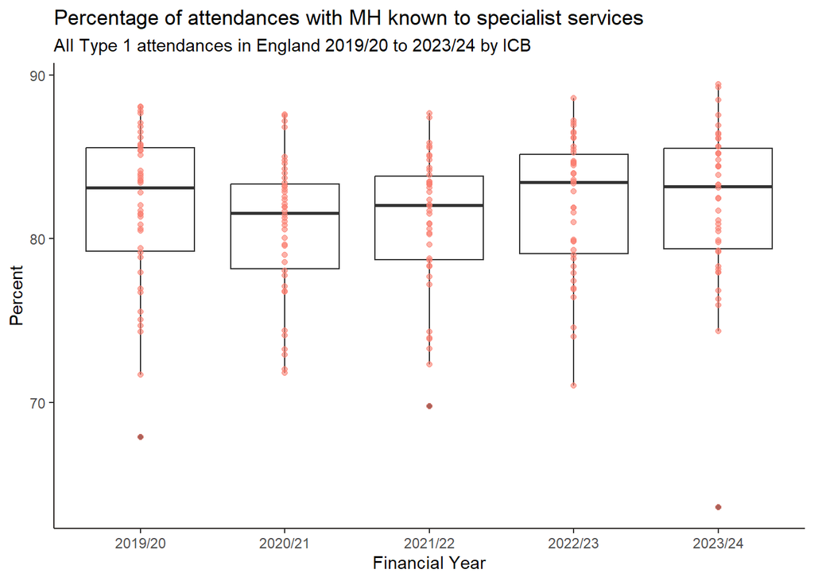

Figure 7: Percentage of Mental Health Type 1 attendances known to specialist services over time.

**ICB Variation**

| ICB | 2019/20 | 2020/21 | 2021/22 | 2022/23 | 2023/24 |
| --- | --- | --- | --- | --- | --- |
| NHS North East London Integrated Care Board | 82.82 | 83.01 | 83.35 | 85.63 | 89.42 |
| NHS Sussex Integrated Care Board | 85.6 | 84.01 | 87.42 | 88.58 | 89.25 |
| NHS South East London Integrated Care Board | 75.55 | 78.04 | 77.22 | 84.72 | 88.48 |
| NHS North West London Integrated Care Board | 81.71 | 83.18 | 85.56 | 86.16 | 87.53 |
| NHS Birmingham and Solihull Integrated Care Board | 88.07 | 84.27 | 85.66 | 85.44 | 86.92 |
| NHS Bedfordshire Luton and Milton Keynes Integrated Care Board | 85.77 | 80.56 | 81.53 | 86.93 | 86.42 |
| NHS Lancashire and South Cumbria Integrated Care Board | 88.02 | 82.86 | 85.04 | 86.51 | 86.38 |
| NHS South Yorkshire Integrated Care Board | 81.48 | 81.92 | 82.39 | 84.67 | 86.15 |
| NHS Dorset Integrated Care Board | 85.37 | 83.71 | 83.28 | 86.18 | 86.09 |
| NHS Leicester Leicestershire and Rutland Integrated Care Board | 87.07 | 87.52 | 85.83 | 86.43 | 85.63 |

[output cut: 32 more lines]

Breakdowns for the number of Type 1 attendances with MH as primary reason/diagnosis where the patient was known to specialist services are below.

**Gender variation**

**Chart**

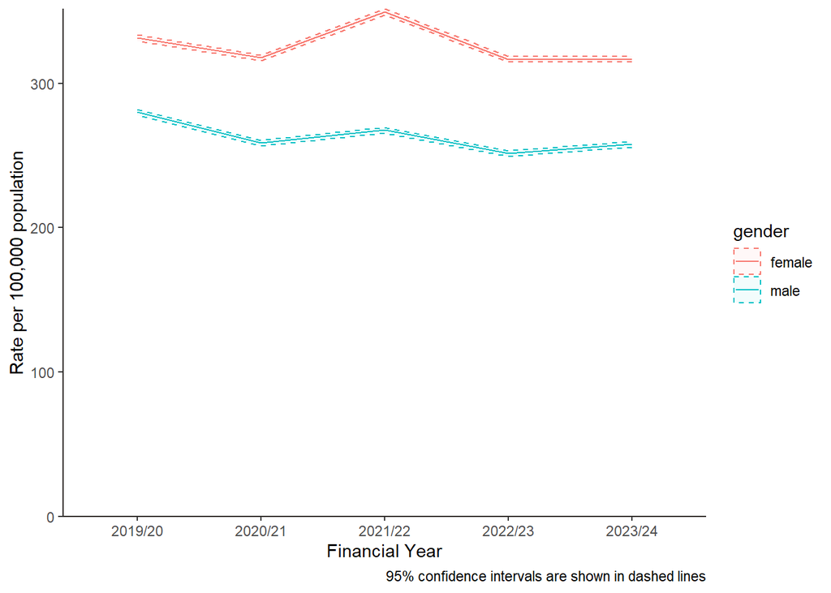

Figure 8: Rates per 100,000 population of the number of Mental Health Type 1 attendances where the patient was known to specialist services by gender.

**Table**

| der_financial_year | gender | attends | count | value | lowercl | uppercl |
| --- | --- | --- | --- | --- | --- | --- |
| 2019/20 | female | 94327 | 28459130 | 331.45 | 329.34 | 333.57 |
| 2020/21 | female | 90738 | 28567320 | 317.63 | 315.57 | 319.7 |
| 2021/22 | female | 100878 | 28871204 | 349.41 | 347.25 | 351.57 |
| 2022/23 | female | 92227 | 29123108 | 316.68 | 314.64 | 318.73 |
| 2023/24 | female | 92231 | 29123108 | 316.69 | 314.65 | 318.74 |
| 2019/20 | male | 77944 | 27827831 | 280.09 | 278.13 | 282.07 |
| 2020/21 | male | 72361 | 27982818 | 258.59 | 256.71 | 260.48 |
| 2021/22 | male | 74077 | 27683687 | 267.58 | 265.66 | 269.52 |
| 2022/23 | male | 70353 | 27983290 | 251.41 | 249.56 | 253.28 |
| 2023/24 | male | 72160 | 27983290 | 257.87 | 255.99 | 259.76 |

**Age-group variation**

**Chart**

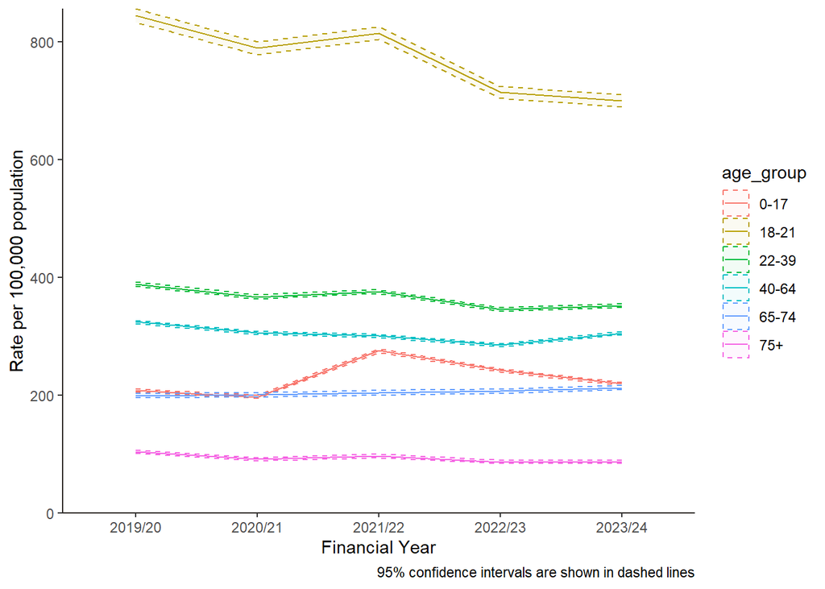

Figure 9: Rates per 100,000 population of the number of Mental Health Type 1 attendances where the patient was known to specialist services by age group.

**Table**

| der_financial_year | age_group | attends | count | value | lowercl | uppercl |
| --- | --- | --- | --- | --- | --- | --- |
| 2019/20 | 0-17 | 24968 | 12023568 | 207.66 | 205.09 | 210.25 |
| 2020/21 | 0-17 | 23848 | 12093288 | 197.2 | 194.71 | 199.72 |
| 2021/22 | 0-17 | 32484 | 11762878 | 276.16 | 273.16 | 279.18 |
| 2022/23 | 0-17 | 28775 | 11886906 | 242.07 | 239.28 | 244.89 |
| 2023/24 | 0-17 | 26081 | 11886906 | 219.41 | 216.75 | 222.09 |
| 2019/20 | 18-21 | 22020 | 2606458 | 844.82 | 833.7 | 856.06 |
| 2020/21 | 18-21 | 20276 | 2569709 | 789.04 | 778.22 | 799.98 |
| 2021/22 | 18-21 | 21182 | 2600225 | 814.62 | 803.69 | 825.67 |
| 2022/23 | 18-21 | 18886 | 2645130 | 713.99 | 703.84 | 724.25 |
| 2023/24 | 18-21 | 18511 | 2645130 | 699.81 | 689.77 | 709.97 |

[output cut: 20 more lines]

**Ethnic group variation**

**Chart**

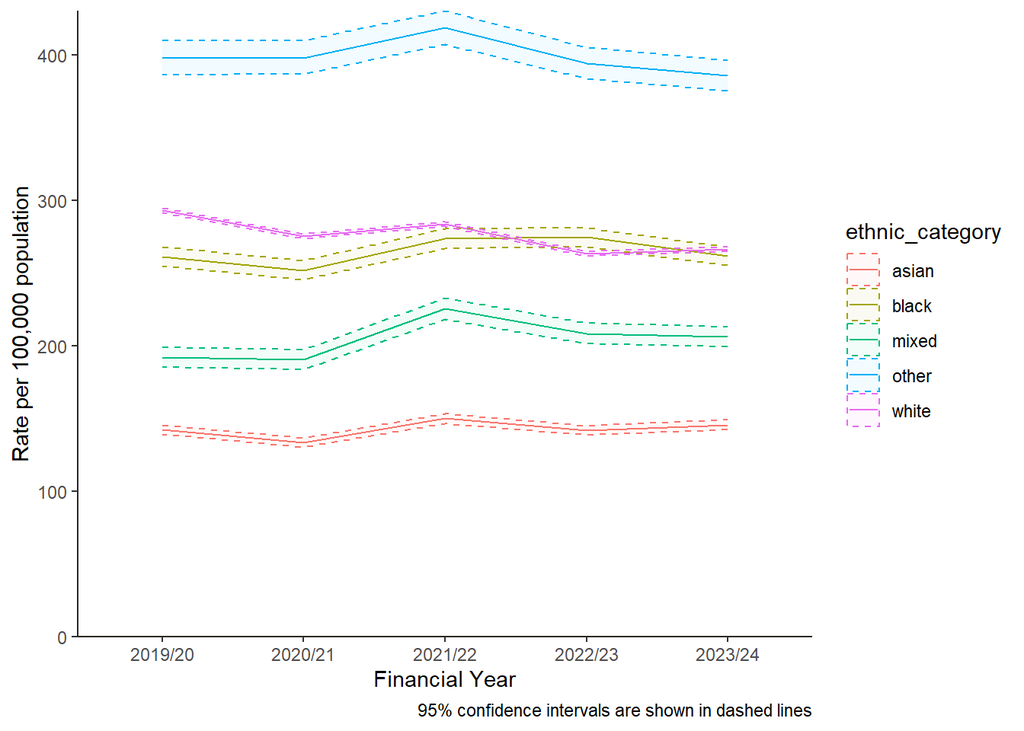

Figure 10: Rates per 100,000 population of the number of Mental Health Type 1 attendances where the patient was known to specialist services by ethnic category.

**Table**

| der_financial_year | ethnic_category | attends | count | value | lowercl | uppercl |
| --- | --- | --- | --- | --- | --- | --- |
| 2019/20 | asian | 7353 | 5169879 | 142.23 | 139 | 145.52 |
| 2020/21 | asian | 7064 | 5298188.5 | 133.33 | 130.24 | 136.47 |
| 2021/22 | asian | 8140 | 5426498 | 150 | 146.76 | 153.3 |
| 2022/23 | asian | 7881 | 5554807.5 | 141.88 | 138.76 | 145.04 |
| 2023/24 | asian | 8283 | 5683117 | 145.75 | 142.63 | 148.92 |
| 2019/20 | black | 5945 | 2274658.8 | 261.36 | 254.76 | 268.09 |
| 2020/21 | black | 5869 | 2328164.4 | 252.09 | 245.68 | 258.62 |
| 2021/22 | black | 6523 | 2381670 | 273.88 | 267.28 | 280.61 |
| 2022/23 | black | 6689 | 2435175.6 | 274.68 | 268.14 | 281.35 |
| 2023/24 | black | 6517 | 2488681.2 | 261.87 | 255.55 | 268.3 |

[output cut: 15 more lines]

**Socioeconomic variation**

**Chart**

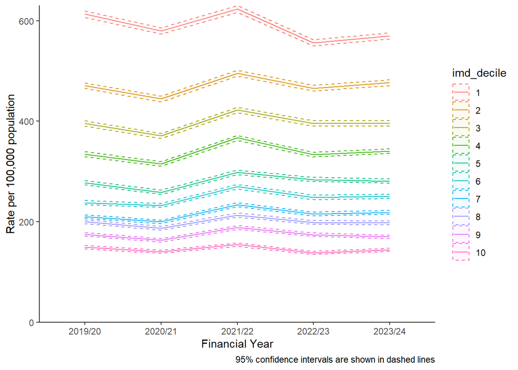

Figure 11: Rates per 100,000 population of the number of Mental Health Type 1 attendances where the patient was known to specialist services by Index of Multiple Deprivation decile.

**Table**

| der_financial_year | imd_decile | attends | count | value | lowercl | uppercl |
| --- | --- | --- | --- | --- | --- | --- |
| 2019/20 | 1 | 34266 | 5588091 | 613.2 | 606.72 | 619.72 |
| 2020/21 | 1 | 32478 | 5603911 | 579.56 | 573.27 | 585.9 |
| 2021/22 | 1 | 33638 | 5394735 | 623.53 | 616.89 | 630.23 |
| 2022/23 | 1 | 30322 | 5453738 | 555.99 | 549.75 | 562.28 |
| 2023/24 | 1 | 31068 | 5453738 | 569.66 | 563.35 | 576.03 |
| 2019/20 | 2 | 26732 | 5677439 | 470.85 | 465.22 | 476.52 |
| 2020/21 | 2 | 25315 | 5697232 | 444.34 | 438.88 | 449.85 |
| 2021/22 | 2 | 26875 | 5422810 | 495.59 | 489.68 | 501.55 |
| 2022/23 | 2 | 25442 | 5463929 | 465.64 | 459.93 | 471.39 |
| 2023/24 | 2 | 26050 | 5463929 | 476.76 | 470.99 | 482.59 |

[output cut: 40 more lines]

**Rural-urban variation**

**Chart**

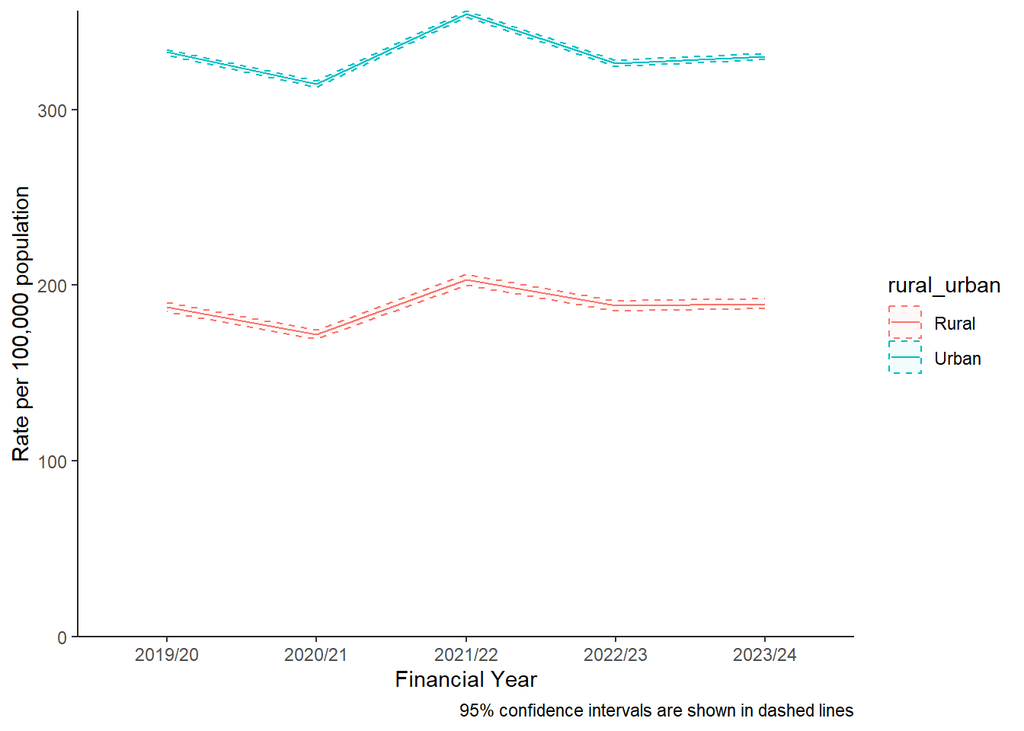

Figure 12: Rates per 100,000 population of the number of Mental Health Type 1 attendances where the patient was known to specialist services by rural and urban populations.

**Table**

| der_financial_year | rural_urban | attends | count | value | lowercl | uppercl |
| --- | --- | --- | --- | --- | --- | --- |
| 2019/20 | Rural | 18021 | 9608249 | 187.56 | 184.83 | 190.32 |
| 2020/21 | Rural | 16665 | 9683314 | 172.1 | 169.5 | 174.73 |
| 2021/22 | Rural | 18687 | 9201537 | 203.09 | 200.18 | 206.02 |
| 2022/23 | Rural | 17474 | 9279480 | 188.31 | 185.53 | 191.12 |
| 2023/24 | Rural | 17585 | 9279480 | 189.5 | 186.71 | 192.33 |
| 2019/20 | Urban | 155259 | 46678712 | 332.61 | 330.96 | 334.27 |
| 2020/21 | Urban | 147456 | 46866824 | 314.63 | 313.02 | 316.24 |
| 2021/22 | Urban | 156654 | 44203614 | 354.39 | 352.64 | 356.15 |
| 2022/23 | Urban | 145317 | 44525824 | 326.37 | 324.69 | 328.05 |
| 2023/24 | Urban | 147070 | 44525824 | 330.3 | 328.62 | 332 |

#### Arrival mode breakdowns

The breakdowns below are for the number of mental health attendances only.

**Gender variation**

**Chart**

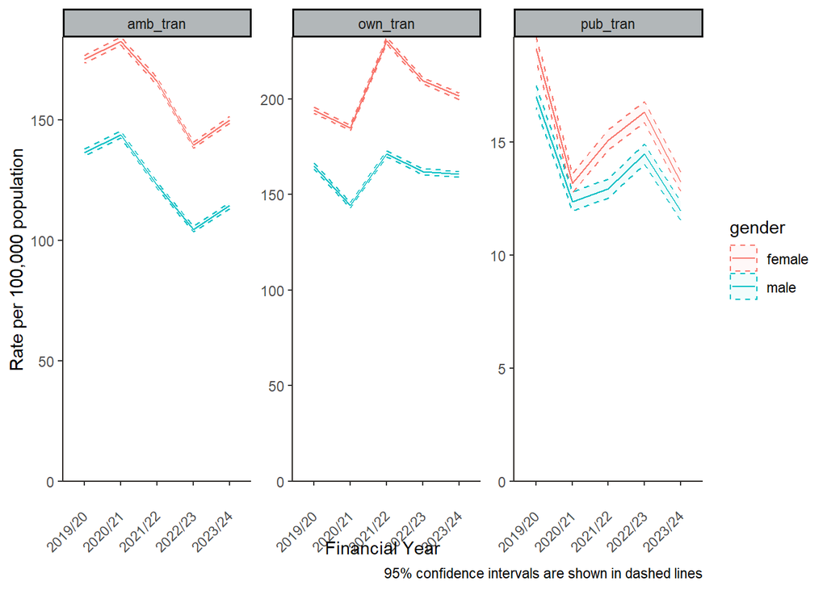

Figure 13: Rates per 100,000 population of the number of Mental Health Type 1 attendances by arrival mode by gender.

**Table**

| der_financial_year | gender | arrival_mode | attends | count | value | lowercl |
| --- | --- | --- | --- | --- | --- | --- |
| 2019/20 | female | amb_tran | 49828 | 28459130 | 175.09 | 173.55 |
| 2019/20 | female | own_tran | 55258 | 28459130 | 194.17 | 192.55 |
| 2019/20 | female | pub_tran | 5444 | 28459130 | 19.13 | 18.62 |
| 2020/21 | female | amb_tran | 52176 | 28567320 | 182.64 | 181.08 |
| 2020/21 | female | own_tran | 52817 | 28567320 | 184.89 | 183.31 |
| 2020/21 | female | pub_tran | 3771 | 28567320 | 13.2 | 12.78 |
| 2021/22 | female | own_tran | 66510 | 28871204 | 230.37 | 228.62 |
| 2021/22 | female | amb_tran | 47929 | 28871204 | 166.01 | 164.53 |
| 2021/22 | female | pub_tran | 4360 | 28871204 | 15.1 | 14.66 |
| 2022/23 | female | amb_tran | 40617 | 29123108 | 139.47 | 138.11 |

[output cut: 20 more lines]

**Age-group variation**

**Chart**

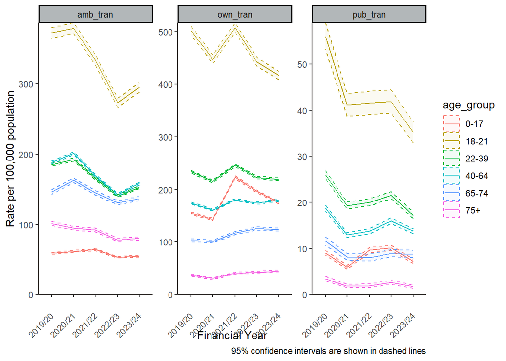

Figure 14: Rates per 100,000 population of the number of Mental Health Type 1 attendances by arrival mode by age group.

**Table**

| der_financial_year | age_group | arrival_mode | attends | count | value | lowercl |
| --- | --- | --- | --- | --- | --- | --- |
| 2019/20 | 0-17 | own_tran | 18563 | 12023568 | 154.39 | 152.18 |
| 2019/20 | 0-17 | amb_tran | 7084 | 12023568 | 58.92 | 57.55 |
| 2019/20 | 0-17 | pub_tran | 1084 | 12023568 | 9.02 | 8.49 |
| 2020/21 | 0-17 | own_tran | 17325 | 12093288 | 143.26 | 141.14 |
| 2020/21 | 0-17 | pub_tran | 720 | 12093288 | 5.95 | 5.53 |
| 2020/21 | 0-17 | amb_tran | 7429 | 12093288 | 61.43 | 60.04 |
| 2021/22 | 0-17 | amb_tran | 7557 | 11762878 | 64.24 | 62.8 |
| 2021/22 | 0-17 | own_tran | 26242 | 11762878 | 223.09 | 220.4 |
| 2021/22 | 0-17 | pub_tran | 1133 | 11762878 | 9.63 | 9.08 |
| 2022/23 | 0-17 | amb_tran | 6318 | 11886906 | 53.15 | 51.85 |

[output cut: 80 more lines]

**Ethnic group variation**

**Chart**

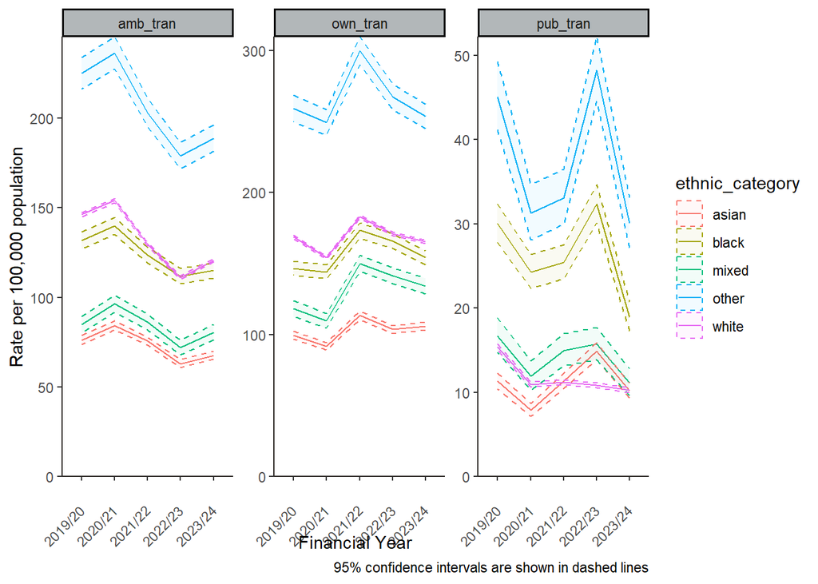

Figure 15: Rates per 100,000 population of the number of Mental Health Type 1 attendances by arrival mode by ethnic category.

**Table**

| der_financial_year | ethnic_category | arrival_mode | attends | count | value | lowercl |
| --- | --- | --- | --- | --- | --- | --- |
| 2019/20 | asian | own_tran | 5147 | 5169879 | 99.56 | 96.86 |
| 2019/20 | asian | amb_tran | 3942 | 5169879 | 76.25 | 73.89 |
| 2019/20 | asian | pub_tran | 586 | 5169879 | 11.33 | 10.44 |
| 2020/21 | asian | pub_tran | 417 | 5298188.5 | 7.87 | 7.13 |
| 2020/21 | asian | amb_tran | 4468 | 5298188.5 | 84.33 | 81.88 |
| 2020/21 | asian | own_tran | 4850 | 5298188.5 | 91.54 | 88.98 |
| 2021/22 | asian | amb_tran | 4103 | 5426498 | 75.61 | 73.31 |
| 2021/22 | asian | own_tran | 6160 | 5426498 | 113.52 | 110.7 |
| 2021/22 | asian | pub_tran | 617 | 5426498 | 11.37 | 10.49 |
| 2022/23 | asian | own_tran | 5754 | 5554807.5 | 103.59 | 100.93 |

[output cut: 65 more lines]

**Socioeconomic variation**

**Chart**

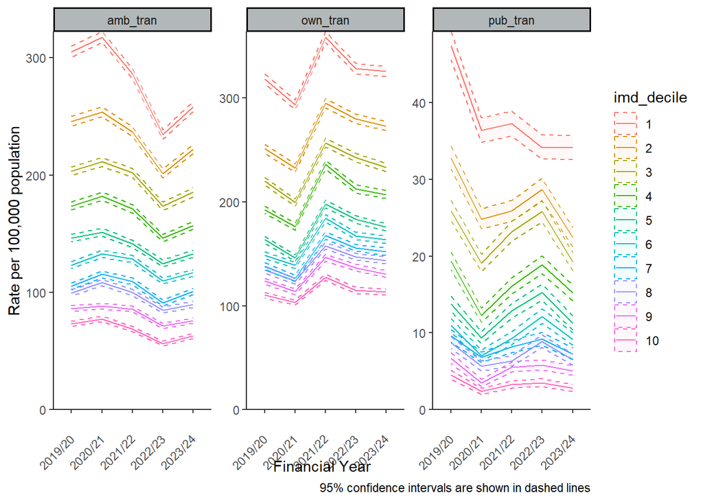

Figure 16: Rates per 100,000 population of the number of Mental Health Type 1 attendances by arrival mode by Index of Multiple Deprivation decile.

**Table**

| der_financial_year | imd_decile | arrival_mode | attends | count | value | lowercl |
| --- | --- | --- | --- | --- | --- | --- |
| 2019/20 | 1 | pub_tran | 2650 | 5588091 | 47.42 | 45.63 |
| 2019/20 | 1 | own_tran | 17799 | 5588091 | 318.52 | 313.85 |
| 2019/20 | 1 | amb_tran | 17057 | 5588091 | 305.24 | 300.67 |
| 2020/21 | 1 | own_tran | 16465 | 5603911 | 293.81 | 289.34 |
| 2020/21 | 1 | amb_tran | 17796 | 5603911 | 317.56 | 312.92 |
| 2020/21 | 1 | pub_tran | 2040 | 5603911 | 36.4 | 34.84 |
| 2021/22 | 1 | amb_tran | 15441 | 5394735 | 286.22 | 281.73 |
| 2021/22 | 1 | own_tran | 19360 | 5394735 | 358.87 | 353.83 |
| 2021/22 | 1 | pub_tran | 2012 | 5394735 | 37.3 | 35.68 |
| 2022/23 | 1 | amb_tran | 12797 | 5453738 | 234.65 | 230.6 |

[output cut: 140 more lines]

**Rural-urban variation**

**Chart**

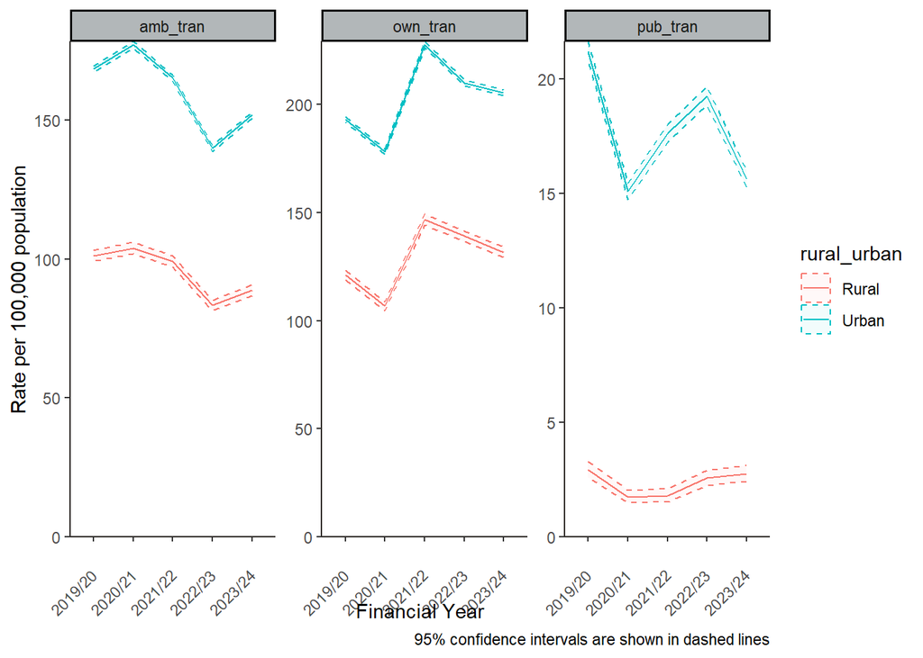

Figure 17: Rates per 100,000 population of the number of Mental Health Type 1 attendances by arrival mode by rural or urban populations.

**Table**

| der_financial_year | rural_urban | arrival_mode | attends | count | value | lowercl |
| --- | --- | --- | --- | --- | --- | --- |
| 2019/20 | Rural | own_tran | 11646 | 9608249 | 121.21 | 119.02 |
| 2019/20 | Rural | amb_tran | 9712 | 9608249 | 101.08 | 99.08 |
| 2019/20 | Rural | pub_tran | 282 | 9608249 | 2.93 | 2.6 |
| 2020/21 | Rural | amb_tran | 10070 | 9683314 | 103.99 | 101.97 |
| 2020/21 | Rural | own_tran | 10345 | 9683314 | 106.83 | 104.78 |
| 2020/21 | Rural | pub_tran | 170 | 9683314 | 1.76 | 1.5 |
| 2021/22 | Rural | own_tran | 13502 | 9201537 | 146.74 | 144.27 |
| 2021/22 | Rural | amb_tran | 9128 | 9201537 | 99.2 | 97.18 |
| 2021/22 | Rural | pub_tran | 166 | 9201537 | 1.8 | 1.54 |
| 2022/23 | Rural | amb_tran | 7732 | 9279480 | 83.32 | 81.48 |

[output cut: 20 more lines]

## Walk-in and Urgent Care attendance

These attendances are those specified within the ECDS as ‘Type 3’ urgent treatment centre and ‘Type 4’ walk-in centre attendances and should be typically self-conveyed patients requiring urgent assessment and treatment to prevent deterioration.

The average urgent care attendance in England costs £107 https://www.england.nhs.uk/costing-in-the-nhs/national-cost-collection/.

### Detailed breakdowns

#### Percentage of all UEC attendances with MH as primary reason/diagnosis

**Overview**

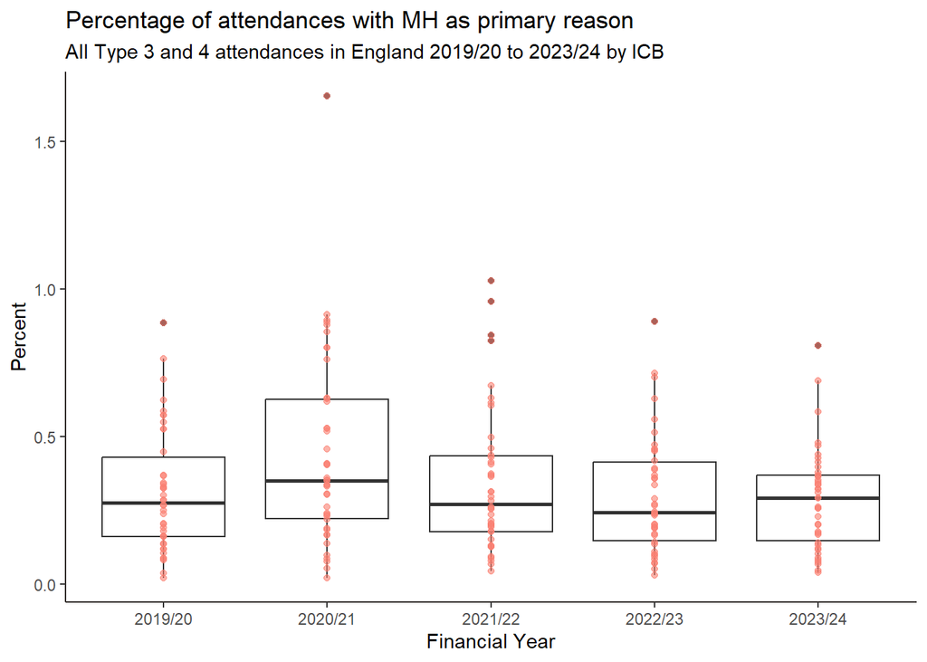

Figure 18: Percentage of Mental Health UEC attendances over time.

**ICB Variation**

| ICB | 2019/20 | 2020/21 | 2021/22 | 2022/23 | 2023/24 |
| --- | --- | --- | --- | --- | --- |
| NHS Sussex Integrated Care Board | 0.89 | 0.8 | 1.03 | 0.89 | 0.81 |
| NHS Northamptonshire Integrated Care Board | 0.53 | 1.65 | 0.96 | 0.7 | 0.69 |
| NHS West Yorkshire Integrated Care Board | 0.7 | 0.88 | 0.67 | 0.56 | 0.58 |
| NHS Greater Manchester Integrated Care Board | 0.59 | 0.63 | 0.31 | 0.36 | 0.48 |
| NHS South East London Integrated Care Board | 0.32 | 0.41 | 0.62 | 0.63 | 0.47 |
| NHS Lincolnshire Integrated Care Board | 0.52 | 0.76 | 0.44 | 0.46 | 0.44 |
| NHS North Central London Integrated Care Board | 0.45 | 0.8 | 0.83 | 0.47 | 0.43 |
| NHS Cornwall and the Isles of Scilly Integrated Care Board | 0.34 | 0.35 | 0.41 | 0.37 | 0.41 |
| NHS Derby and Derbyshire Integrated Care Board | 0.16 | 0.53 | 0.84 | 0.72 | 0.4 |
| NHS Mid and South Essex Integrated Care Board | 0.62 | 0.85 | 0.63 | 0.51 | 0.38 |

[output cut: 32 more lines]

Breakdowns for the number of attendances to UEC with MH as primary reason/diagnosis are below.